# IDazketa Aztertzeko Tresnaren (IDAT): lehenengo emaitzak

Juan Abasolo

Aitor Iglesias

Lorea Unamuno

SEDLLen XXI. Nazioarteko Kongresua 2020-11-27 Iruñea

### Oinarritzea

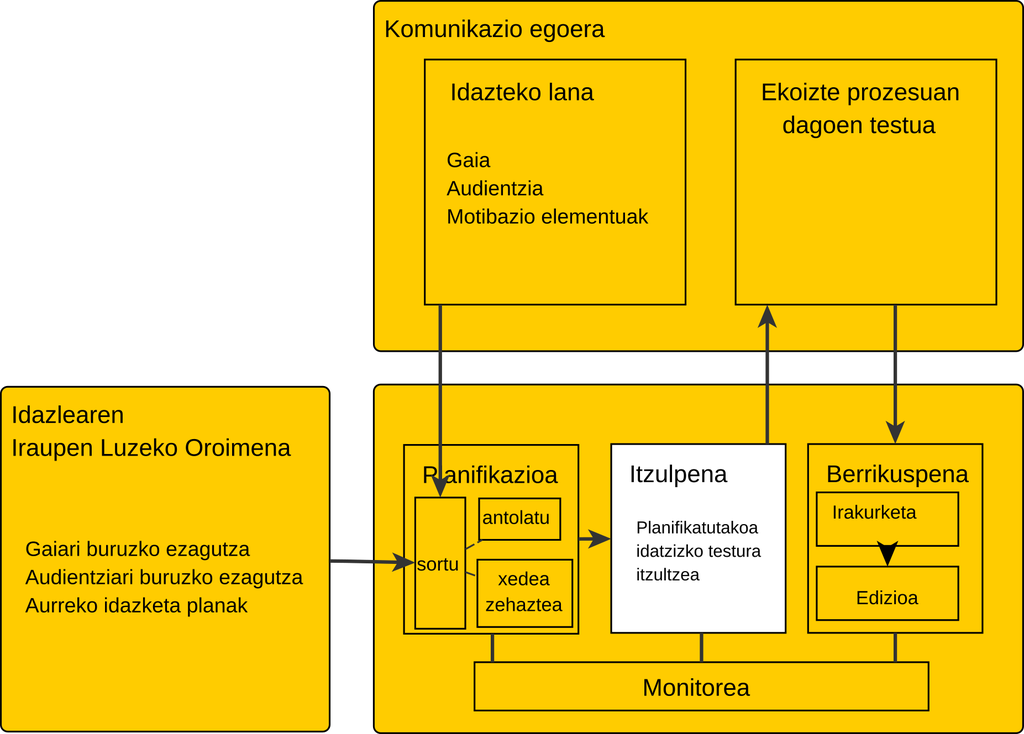

Hizkuntza idatziaren (denbora) ezaugarriak: “Structure of the Writing Model”-en itzulpena, Hayes & Flower, 1980:208

### Helburuak

## Xedea

- IDAT idazketaren ezaugarri tenporalen azterketarako doitzea

## Helburu zehatza

Idazketa prozesuaren ezaugarri tenporalak aztertu ezaugarri kualitatibo batzuen arabera.

### Metodologia

## Tresnak

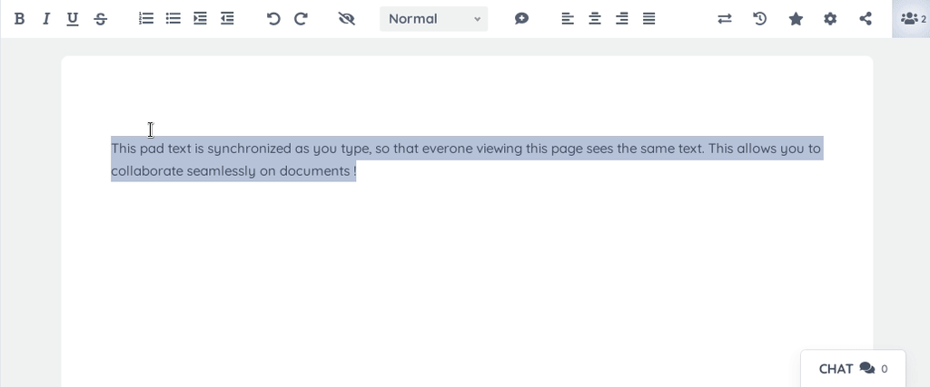

Etherpad

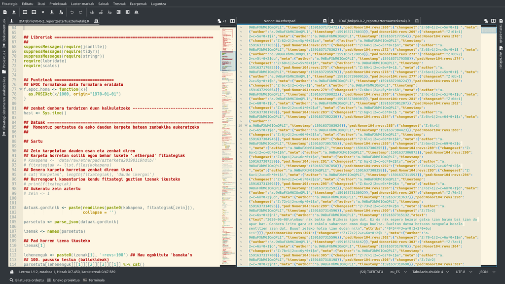

Etherpad eta IDAT

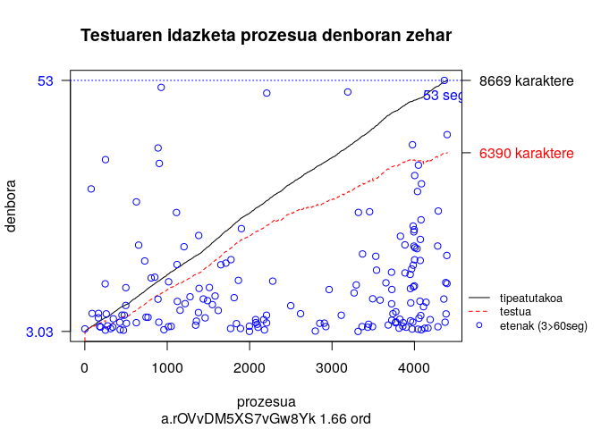

IDAT

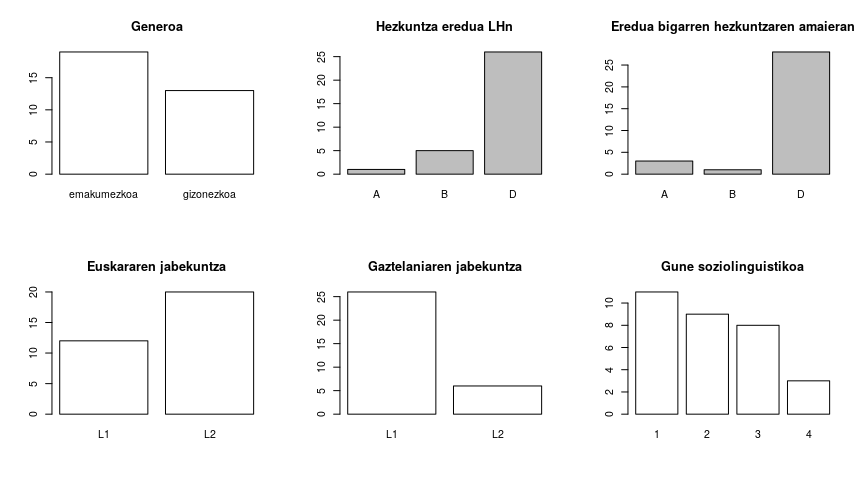

Lagina

## Aldagaiak

- Deskribatzaile kualitatiboak
- Jardunaren ezaugarri kuantitatiboak

## Kontraste motak

`Wilcoxon-Mann-Withney`

### Emaitzak

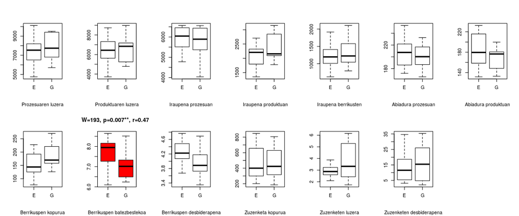

Generoa eta…

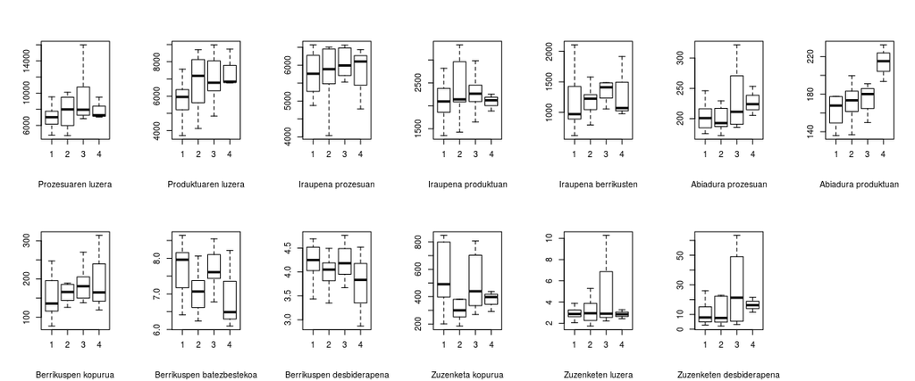

Gune soziolinguistikoa eta…

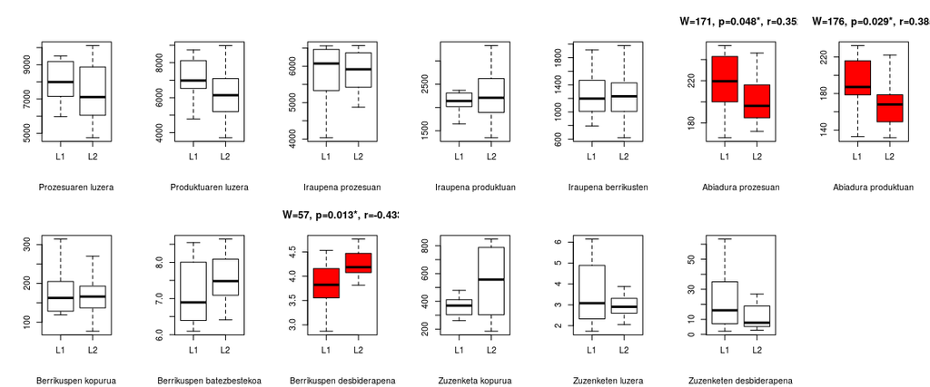

Euskararen jabekuntza eta…

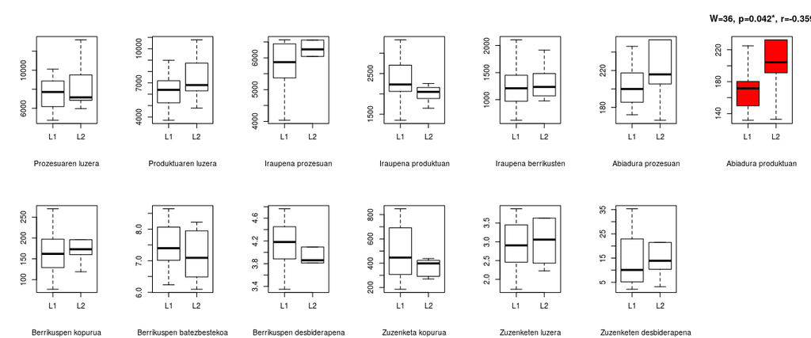

Gaztelaniaren jabekuntza eta…

## Efektuaren tamainaz

Euskara L1 bizkorrago prozesuan `r = 0.352`

**Euskara L1 bizkorrago produktuan `r = 0.385`**

Gaztelania L2 bizkorrago produktuan `r = 0.359`

### Ondorioak

## Desberdintasun adierazgarriak, efektu ertainak

## Desberdintasunak aurkitu dira!

# Erreferentziak

Abasolo, J., Unamuno, L., & de Pablo, I. (2018, azaroak 20). *Idazketa aztertzeko tresna*. XXV. psikodidaktika jardunaldiak / XXV Jornadas de Psicodidáctica, Vitoria-Gasteiz.

Conijn, R., Roeser, J., & van Zaanen, M. (2019). Understanding the keystroke log: The effect of writing task on keystroke features. *Reading and Writing*, *32*(9), 2353–2374. https://doi.org/10/ggjr78

Flower, L., & Hayes, J. R. (1981). A Cognitive Process Theory of Writing. *College Composition and Communication*, *32*(4), 365. https://doi.org/10/bn59g4

Greenspan, D., Iba, A., & Zamfirescu, J. D. (2008). *Etherpad: Really real-time collaborative document editing* (1.7) [JavaScript]. Etherpad. http://etherpad.org

Hayes, J. R., & Flower, L. (1980). Identifying the organization of writing processes. *Cognitive processes in Writing*. https://ci.nii.ac.jp/naid/10010327319/

Ihaka, R., & Gentleman, R. (1996). R: A Language for Data Analysis and Graphics. *Journal of Computational and Graphical Statistics*, *5*(3), 299–314. https://doi.org/10/gddc3n

Kollberg, P., Kim, H.-C., & Severinson-Eklundh, K. (1996). Trace-it: An interactive tool for revision analysis. *European writing conferences barcelona, spain*, 23–25.

Leijten, M., & Van Waes, L. (2005). *Inputlog: A logging tool for the research of writing processes*. 22.

Leijten, M., & Van Waes, L. (2013). Keystroke Logging in Writing Research: Using Inputlog to Analyze and Visualize Writing Processes. *Written Communication*, *30*(3), 358–392. https://doi.org/10/f5q5cm

Matsuhashi, A. (1981). Pausing and Planning: The Tempo of Written Discourse Production. *Research in the Teaching of English*, *15*(2), 113–134.

Severinson-Eklundh, K., & Kollberg, P. (1992). Translating keystroke records into a general notation for the writing process (IPLab-59). *Stockholm: Department of Numerical Analysis and Computing Science, Royal Institute of Technology*.

# IDazketa Aztertzeko Tresnaren (IDAT): lehenengo emaitzak

juan.abasolo@ehu.eus  
aitor.iglesias@ehu.eus  
lorea.unamuno@ehu.eus